# diabetesEli

Elizabeth Cattaneo

8/20/2022

**Objetivo:** Desarrollar un modelo de clasificación para diabetes.

**Datos:** dataset descargado de la plataforma [kaggle](https://www.kaggle.com/competitions/diabetes-classification/overview)

**Variables de la base:**

1. Number of times pregnant
2. Plasma glucose concentration a 2 hours in an oral glucose tolerance test
3. Diastolic blood pressure (mm Hg)
4. Triceps skin fold thickness (mm)
5. 2-Hour serum insulin (mu U/ml)
6. Body mass index (weight in kg/(height in m)^2)
7. Diabetes pedigree function
8. Age (years)
9. Class variable (0 or 1)
- Class variable es la variable a predecir y toma los valores:
  - 0 si la persona no es diabética
  - 1 si la persona es diabética

**Tipos de modelos para clasificar variables categóricas:**

- Regresión logística (simple o múltiple)
- Decision tree -> library(rpart) para crear el árbol y library(rpart.plot) para visualizarlo
- Random Forest -> library(randomForest)
- Red neuronal -> library(neuralnet)

**Pasos para el desarrollo del modelo:**

1. Cargar los datos
2. Explorarlos (EDA: Exploraory Data Analysis)
3. Separarlos en entrenamiento (TR) y testeo (TS)
4. Crear el modelo con los datos de TR
5. Calcular las predicciones para los 2 sets de datos (TR y TS)
6. Validar

**Bibliografía**

[Acá](https://www.cienciadedatos.net/documentos/27_regresion_logistica_simple_y_multiple#Regresi%C3%B3n_log%C3%ADstica_m%C3%BAltiple) hay info sobre regresión logística simple y múltiple.

```r
# cargo librerias
library(tidyverse)
```

```r
library(corrplot)
```

### **Paso 1: Cargar los datos**

```r
diabetes<-read.csv("diabetes.csv")
```

### **Paso 2: EDA**

```r
# general
str(diabetes)
```

```
## 'data.frame':    768 obs. of  9 variables:
##  $ Pregnancies             : int  6 1 8 1 0 5 3 10 2 8 ...
##  $ Glucose                 : int  148 85 183 89 137 116 78 115 197 125 ...
##  $ BloodPressure           : int  72 66 64 66 40 74 50 0 70 96 ...
##  $ SkinThickness           : int  35 29 0 23 35 0 32 0 45 0 ...
##  $ Insulin                 : int  0 0 0 94 168 0 88 0 543 0 ...
##  $ BMI                     : num  33.6 26.6 23.3 28.1 43.1 25.6 31 35.3 30.5 0 ...
##  $ DiabetesPedigreeFunction: num  0.627 0.351 0.672 0.167 2.288 ...
##  $ Age                     : int  50 31 32 21 33 30 26 29 53 54 ...
##  $ Outcome                 : int  1 0 1 0 1 0 1 0 1 1 ...
```

#### **Modelo 1: Regresión Logística**

Método de regresión que permite estimar la probabilidad de una variable cualitativa binaria en función de variables cuantitativas y/o categóricas. Es decir, permite calcular la probabilidad de que la variable dependiente pertenezca a cada una de las dos categorías en función de los valores que adquieran las variables independientes.

- Para hacerla se utiliza stat::glm() (generalized linear model).
- La variable de salida debe ser factor.
- Para ver como se relaciona la variable de salida con las variables de entrada se pueden visualizar los coeficientes de correlación utilizando [corrplot](https://cran.r-project.org/web/packages/corrplot/vignettes/corrplot-intro.html)

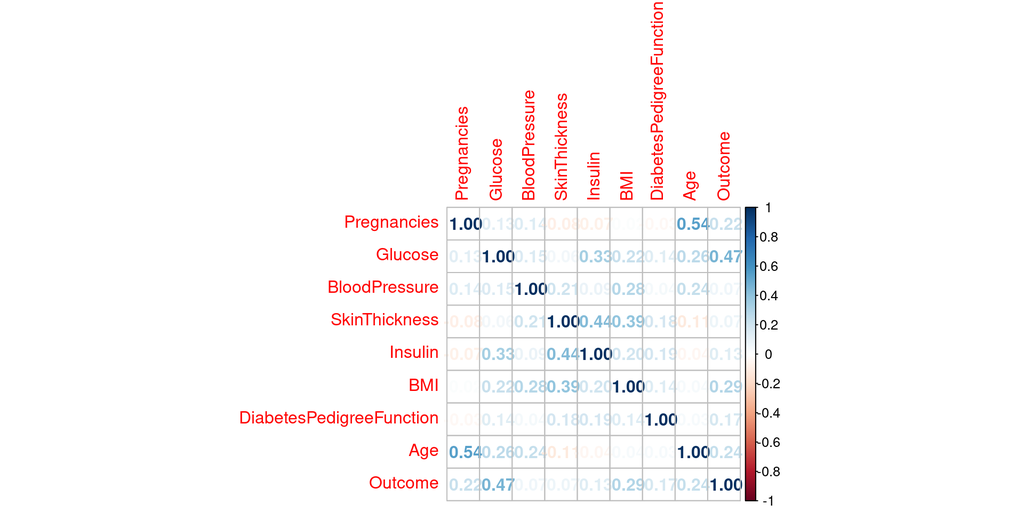

```r
# visualizacion de los coef de correlacion
corrplot(cor(diabetes), method = "number")
```

```r
# chequeo variable de salida
class(diabetes$Outcome)
```

```
## [1] "integer"
```

```r
# la transformo en factor y chequeo
diabetes$Outcome <- as.factor(diabetes$Outcome)
class(diabetes$Outcome)
```

```
## [1] "factor"
```